# Case 3: Økonomisk aktivitet, $CO_2$ og global temperatur

Vi skal her se nærmere på økonomisk aktivitet målt med bruttonasjonalprodukt (BNP), globale utslipp av $CO_2$ og global temperatur.

Brutto nasjonalprodukt og populasjonstall kommer fra [Maddison Project Database 2020](https://www.rug.nl/ggdc/historicaldevelopment/maddison/releases/maddison-project-database-2020) et non-profit prosjekt drevet av forskere ved Universitetet i Groningen.

For utslippsdata av $CO_2$ benytter vi oss av data fra [Our World in Data](https://ourworldindata.org/co2-and-other-greenhouse-gas-emissions) et non-profit prosjekt drevet av forskere ved Universitet i Oxford.

Temperaturdata stammer fra [Met Office](https://www.metoffice.gov.uk/hadobs/hadcrut4/data/current/download.html), UKs nasjonale meteorologiske institutt.

Vi laster nødvendige pakker.

```r
library(tidyverse)
library(data.table)
library(cowplot)
library(corrr)
library(readxl)
library(httr)
```

## Data fra kode

Vi starter med å laste ned $CO_2$ data. En oversikt over data med beskrivelse finner vi på prosjektets [github side](https://github.com/owid/co2-data). Vi laster også ned kodebok med variabelbeskrivelse. Tabellene er lagret som `.CSV` filer, dvs komma separerte tekstfiler. Funksjonen `data.table::fread()` gjør jobben for oss.

```r
co2 <- fread("https://github.com/owid/co2-data/raw/master/owid-co2-data.csv")
codebook <- fread("https://github.com/owid/co2-data/raw/master/owid-co2-codebook.csv")
```

Vi ser at det er data fra enkeltland og samlekategorier for ulike regioner, med ulikt antall observasjoner.

```r
with(co2, table(country))
```

```
country
                     Afghanistan                           Africa
                              71                              136
                         Albania                          Algeria
                              87                              104
                         Andorra                           Angola
                              30                               70
                        Anguilla              Antigua and Barbuda
                              30                               63
                       Argentina                          Armenia
                             133                              190
                           Aruba                             Asia
                              94                              190
      Asia (excl. China & India)                        Australia
                             190                              160
                         Austria                       Azerbaijan
                             202                              190
                         Bahamas                          Bahrain
                              70                               87
                      Bangladesh                         Barbados
                              74                               92
                         Belarus                          Belgium
                             190                              191
                          Belize                            Benin
                              70                               62
                         Bermuda                           Bhutan
                              70                               50
                         Bolivia  Bonaire Sint Eustatius and Saba
                              92                               94
          Bosnia and Herzegovina                         Botswana
                             135                               48
                          Brazil           British Virgin Islands
                             119                               58
                          Brunei                         Bulgaria
                              87                              139
                    Burkina Faso                          Burundi
                              62                               70
                        Cambodia                         Cameroon
                              65                               70
                          Canada                       Cape Verde
```

[output cut: 182 more lines]

```
                              30                               70
                         Ukraine             United Arab Emirates
                             190                               61
                  United Kingdom                    United States
                             270                              220
                         Uruguay                       Uzbekistan
                              88                              190
                         Vanuatu                        Venezuela
                              58                              109
                         Vietnam        Wallis and Futuna Islands
                             128                               19
                           World                            Yemen
                             270                               70
                          Zambia                         Zimbabwe
                              70                              117
```

Vi velger å ekskludere alle samlekategorier og regioner, og ønsker å ta vare på data fra de enkelte land. Variabelen `co2` er utslipp av karbondioksyd målt i millioner tonn. Vi beregner gjennomsnittlig $CO_2$ utslipp per land per år. Først filtrerer vi vekk ulike samlekategorier av land.

```r
co2 <-
  co2 %>%
  filter(country %in% c("Africa", "Asia", "Asia (excl. China & India)",
                        "Europe", "EU-27", "EU-28", "Europe (excl. EU-28)",
                        "Europe (excl. EU-27)", "Oceania", "North America",
                        "North America (excl. USA)", "Panama Canal Zone",
                        "South America", "International transport",
                        "Kuwaiti Oil Fires") == FALSE) %>%
  select(year, co2) %>%
  group_by(year) %>%
  summarise(co2 = mean(co2, na.rm = TRUE)) %>%
  ungroup()
head(co2)
```

```
# A tibble: 6 x 2
   year   co2
  <int> <dbl>
1  1750  9.35
2  1751  9.35
3  1752  9.35
4  1753  9.35
5  1754  9.36
6  1755  9.36
```

Data på brutto-nasjonalprodukt per capita hentes fra [Maddison Project Database (MPD) 2020](https://www.rug.nl/ggdc/historicaldevelopment/maddison/releases/maddison-project-database-2020). Vi benytter kode som laster datafila direkte fra kilde som en temporær fil. Den er lagret i excel format, og fanen med data heter `Full data`.

```r
url <- "https://www.rug.nl/ggdc/historicaldevelopment/maddison/data/mpd2020.xlsx"
GET(url, write_disk(tmpfi <- tempfile(fileext = ".xlsx")))
```

```
Response [https://www.rug.nl/ggdc/historicaldevelopment/maddison/data/mpd2020.xlsx]
  Date: 2021-07-14 19:24
  Status: 200
  Content-Type: application/vnd.openxmlformats-officedocument.spreadsheetml.sheet;charset=UTF-8
  Size: 1.76 MB
<ON DISK>  /tmp/RtmpiFnm0k/file2fa7496f3347.xlsx
```

```r
mpd2020 <- read_excel(tmpfi, sheet = "Full data")
head(mpd2020)
```

```
# A tibble: 6 x 5
  countrycode country      year gdppc   pop
  <chr>       <chr>       <dbl> <dbl> <dbl>
1 AFG         Afghanistan  1820    NA  3280
2 AFG         Afghanistan  1870    NA  4207
3 AFG         Afghanistan  1913    NA  5730
4 AFG         Afghanistan  1950  1156  8150
5 AFG         Afghanistan  1951  1170  8284
6 AFG         Afghanistan  1952  1189  8425
```

Vi beregner gjennomsnittlig BNP per capita per år for alle landene i tabellen.

```r
gdp <-
  mpd2020 %>%
    select(year, gdppc) %>%
    filter(year >= 1750) %>%
  group_by(year) %>%
  summarise(bnp_pc = mean(gdppc, na.rm = TRUE)) %>%
  ungroup()
head(gdp)
```

```
# A tibble: 6 x 2
   year bnp_pc
  <dbl>  <dbl>
1  1750  1699.
2  1751  2086.
3  1752  2085.
4  1753  2134.
5  1754  2075.
6  1755  2010.
```

Deretter laster vi ned temperaturdata. Dette er medianverdien per år for et ensemble av 100 målinger. Tidsserien blir presentert som avvik (grader celcius) fra gjennomsnittet i perioden 1961-1990. Dataene er i en textfil uten variabelnavn. Funksjonen `data.table::fread()` angir nye variabelnavn som `V1, V2` osv.

```r
temp <- fread("https://www.metoffice.gov.uk/hadobs/hadcrut4/data/current/time_series/HadCRUT.4.6.0.0.annual_ns_avg.txt")
```

Vi gir variablene nye navn.

```r
temp <-
  temp %>%
  select(V1, V2) %>%
  rename(year = V1,
         temperatur = V2)
head(temp)
```

```
   year temperatur
1: 1850     -0.373
2: 1851     -0.218
3: 1852     -0.228
4: 1853     -0.269
5: 1854     -0.248
6: 1855     -0.272
```

Til sist så slår vi sammen de tre datasettene. Den endelige datatabellen kalles `dframe`. Vi starter tidsserien der vi har komplette observasjoner for alle variablene. Vi benytter variabelen `year` som felles nøkkel for å slå sammen tabellene. Vi beholder data fra og med 1850.

```r
left_join(co2, gdp, by="year") %>%
  left_join(., temp, by="year") -> dframe

dframe <-
  dframe %>%
  filter(year >= 1850)
head(dframe)
```

```
# A tibble: 6 x 4
   year   co2 bnp_pc temperatur
  <dbl> <dbl>  <dbl>      <dbl>
1  1850  13.1  1834.     -0.373
2  1851  26.5  2159.     -0.218
3  1852  27.7  2264.     -0.228
4  1853  29.0  2316.     -0.269
5  1854  34.0  2321.     -0.248
6  1855  17.3  2279.     -0.272
```

Vi lager et plot av de tre tidsseriene. Vi benytter oss av funksjonen [`cowplot::plot_grid()`](https://wilkelab.org/cowplot/articles/plot_grid.html) for å arrangere de tre figurene ved siden av hverandre.

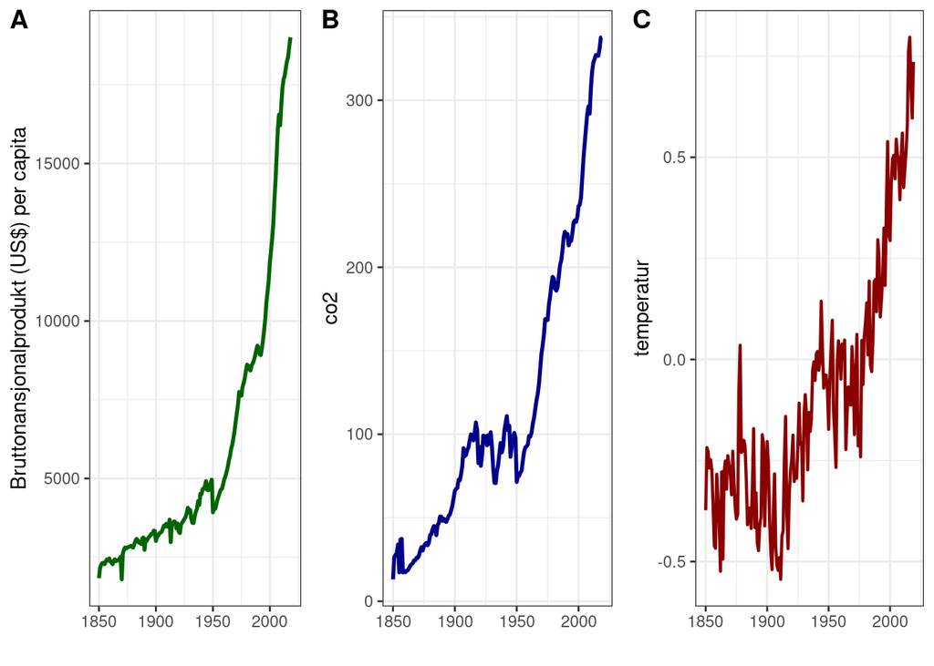

```r
p1 <-
  dframe %>%
  ggplot(aes(x=year, y=bnp_pc)) +
  geom_line(lwd=1, col="dark green") +
  labs(x = " ",
       y = "Bruttonansjonalprodukt (US$) per capita") +
  theme_bw()

p2 <-
  dframe %>%
  ggplot(aes(x=year, y=co2)) +
  geom_line(lwd=1, col="dark blue") +
  labs(x = " ") +
  theme_bw()

p3 <-
  dframe %>%
  ggplot(aes(x=year, y=temperatur)) +
  geom_line(lwd=0.8, col="dark red") +
  labs(x = " ") +
  theme_bw()

plot_grid(p1, p2, p3, ncol = 3, labels = "AUTO")
```

Vi ser at alle tre seriene følger et samenfallende mønster. Legg spesielt merke til økningen fra og med 1950, noen år etter at andre verdenskrig var over.

Korrelasjonen mellom de ulike tidsseriene kan også beregnes.

```r
dframe %>%
  select(-year) %>%
  correlate(diagonal = 1) %>%
  fashion(decimals = 3)
```

```
        term   co2 bnp_pc temperatur
1        co2 1.000   .972       .880
2     bnp_pc  .972  1.000       .899
3 temperatur  .880   .899      1.000
```

### Oppgave 1

Lag to spredningsplott (“scatterplot” bruk `ggplot::geom_point`) av gdp/co2 og co2/temperatur. Kommenter det du ser.

### Oppgave 2

Del datasettet i to, før og etter 1950. Hvor er korrelasjonen mellom variablene størst? I første eller andre del av dataene?

## Modellere sammenhenger?

Hypotesen vår er at BNP påvirker $CO_2$, og deretter påvirker $CO_2$ temperatur.

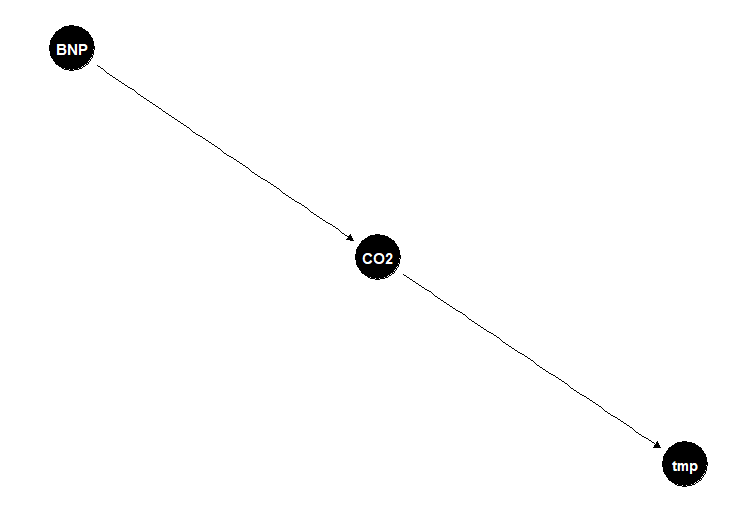

**Figur over sammenhenger?**

## Estimerer regresjonsmodeller

Vi skal estimerer en lineær-logaritmisk regresjonsmodell: $y=\alpha+\beta \times \texttt{log}(x)$. I den første modellen er $CO_2$ den avhengig variabelen som blir forklart av $BNP$, den uavhengig variabelen. Du kan lese litt om denne typen modeller [her](https://kenbenoit.net/assets/courses/ME104/logmodels2.pdf).

Tolkning av $\beta$ parameteret. En 1% endring i $x$ fører til en $\frac{\beta}{100}$ enhets endring i $y$.

### Modell 1: Hele perioden

```r
library(mosaic)
fit1 <- lm(co2 ~ log(bnp_pc), data = dframe)
fit1
```

```
Call:
lm(formula = co2 ~ log(bnp_pc), data = dframe)

Coefficients:
(Intercept)  log(bnp_pc)
    -1068.1        139.8
```

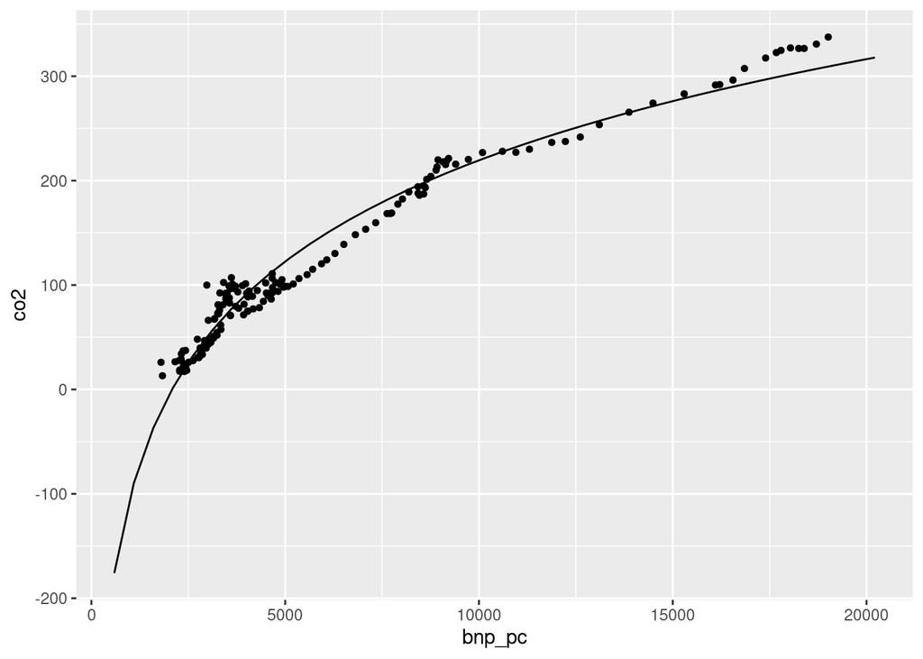

```r
plotModel(fit1)
```

### Modell 2: Før 1950

```r
fit2 <- lm(co2 ~ log(bnp_pc), data = filter(dframe, year < 1950))
fit2
```

```
Call:
lm(formula = co2 ~ log(bnp_pc), data = filter(dframe, year <
    1950))

Coefficients:
(Intercept)  log(bnp_pc)
     -900.4        119.4
```

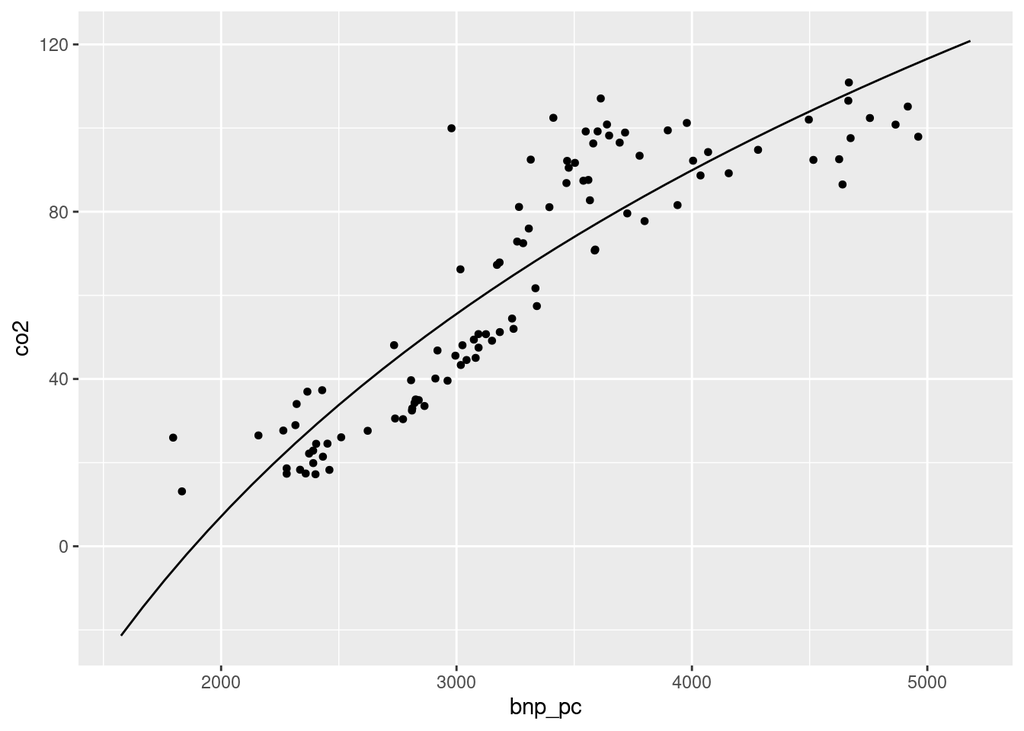

```r
plotModel(fit2)
```

### Modell 3: Etter 1950

```r
fit3 <- lm(co2 ~ log(bnp_pc), data = filter(dframe, year >= 1950))
fit3
```

```
Call:
lm(formula = co2 ~ log(bnp_pc), data = filter(dframe, year >=
    1950))

Coefficients:
(Intercept)  log(bnp_pc)
    -1338.9        169.1
```

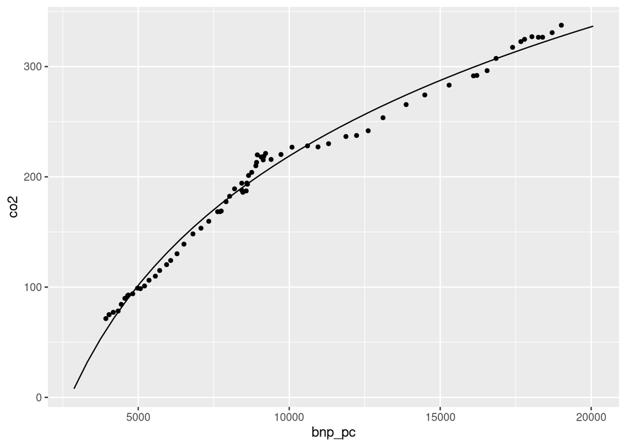

```r
plotModel(fit3)
```

### Modell 4: Begge periodene i samme modell

```r
dframe <- dframe %>%
  mutate(y1950 = year >= 1950)

fit4 <- lm(co2 ~ log(bnp_pc)*y1950, data = dframe)
fit4
```

```
Call:
lm(formula = co2 ~ log(bnp_pc) * y1950, data = dframe)

Coefficients:
          (Intercept)            log(bnp_pc)              y1950TRUE
              -900.40                 119.40                -438.52
log(bnp_pc):y1950TRUE
                49.74
```

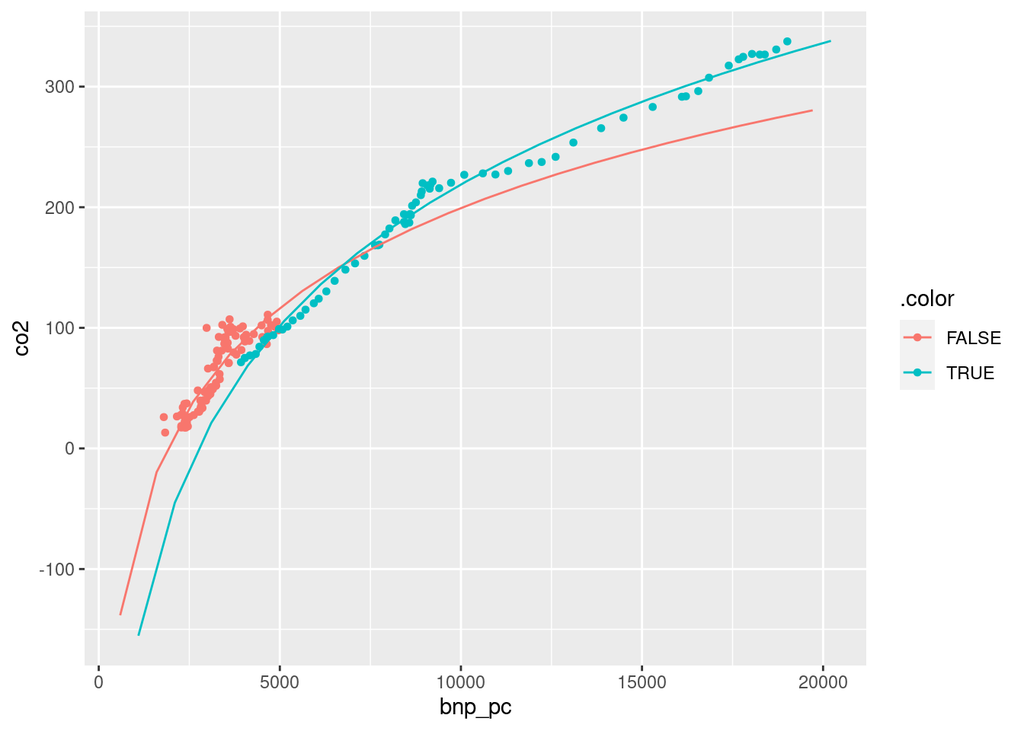

```r
plotModel(fit4)
```

#### Etter 1950 fra modell 4

```r
coef(fit4)[1]+coef(fit4)[3]
```

```
(Intercept)
   -1338.92
```

```r
coef(fit4)[2]+coef(fit4)[4]
```

```
log(bnp_pc)
   169.1364
```

## Påvirker $CO_2$ nivå temperatur?

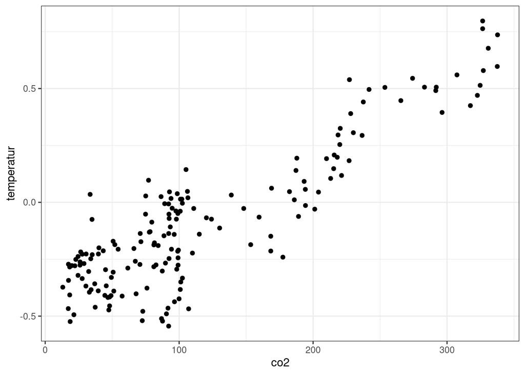

```r
  dframe %>%
  ggplot(aes(x=co2, y=temperatur)) +
  geom_point() +
  theme_bw()
```

### Oppgave 3

Estimer en regresjonsmodell der $CO_2$ påvirker temperatur.

## `R` kode fra dette caset

```r
getwd()
setwd("~/undervisning/SOK1004")
knitr::purl("case_3_bnp_co2_temp.Rmd")
```